# Comunicate Data Findings-Prosper Loan

## Dataset Overview

the dataset contains 113,937 loans with 81 variables. it is very hard and time consuming to figure out what the main features of interest by testing all variables one by one. Based on common sense and my experience in finance, I found that some features are more interesting than others. in this project, I mainly focus on Borrower APR, Prosper Score, Original Loan Amount, Borrower Occupation, Borrower State, Borrower Employment Status and some other feature if it seems interest later on. in my preliminary analysis, i selected columns that i was interested in to make futher investigation.

## Univariate Exploration

### Borrower APR

it is interesting to see that there is a spike at around 0.36. and the shape looks right skewed.

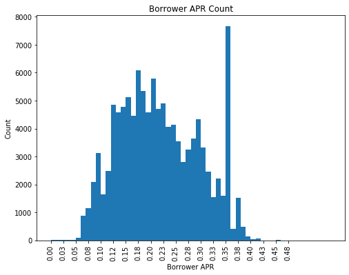

```python
# start with a standard-scaled plot
bins = np.arange(0,prosper_loan['BorrowerAPR'].max()+0.05,0.01)
ticks =list(np.arange(0, 0.5, 0.025))
labels = ['{:.2f}'.format(v) for v in ticks]
plt.xticks(ticks, labels)
plt.xticks(rotation = 90);

plt.hist(data = prosper_loan, x = 'BorrowerAPR',bins = bins);
plt.xlabel('Borrower APR')
plt.ylabel('Count')
plt.title('Borrower APR Count');
```

### Prosper Score

the distribution of prosper score looks normal distributed. scores of 4, 6 and 8 are the most common rating.

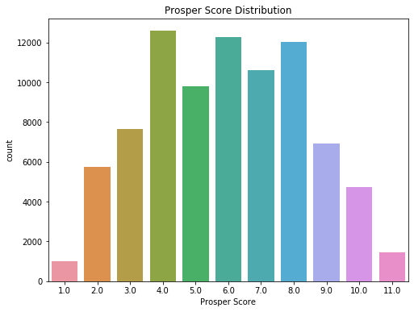

```python
sb.countplot(data =prosper_loan,x= 'ProsperScore')

plt.title('Prosper Score Distribution')

plt.xlabel('Prosper Score');
```

### Employment Status

the biggest group of people who get loans are employed people.

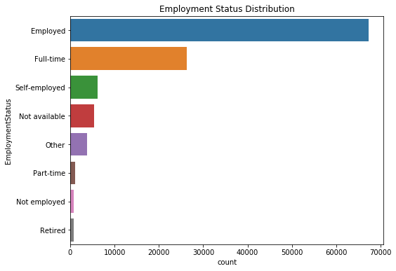

```python
#Borrower Employment Status Distrobution
order = prosper_loan.EmploymentStatus.value_counts().index
sb.countplot(data = prosper_loan,y = 'EmploymentStatus', order = order);
plt.title('Employment Status Distribution')
```

## Bivariate Exploration

### Prosper Score vs Borrwer APR

this is consistent with our analysis before, higher prosper score will lead to lower Borrwoer APR.

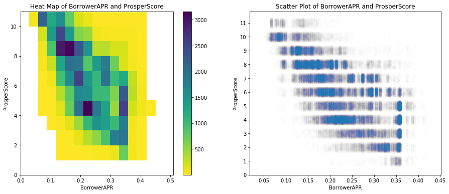

```python
# add jitter function

def rand_jitter(x, jitter = 0.3, random_state = 42):
    rnd_state = np.random.RandomState(random_state)
    return x + rnd_state.uniform(-jitter, +jitter, x.shape)

# add jitter to Prosper Score
prosper_loan['ProsperScore_jitter'] = rand_jitter(prosper_loan.ProsperScore);

# relation between ProsperScore and BorrowerAPR
plt.figure(figsize=[15,6])
#heatmap
plt.subplot(1, 2, 1)
bins_x = np.arange(0, prosper_loan['BorrowerAPR'].max()+0.02, 0.03)
bins_y = np.arange(0, prosper_loan['ProsperScore'].max()+1, 1)
plt.hist2d(data =prosper_loan, x = 'BorrowerAPR', y = 'ProsperScore', bins = [bins_x, bins_y],
               cmap = 'viridis_r', cmin = 0.5)

plt.colorbar()
plt.title('Heat Map of BorrowerAPR and ProsperScore')
plt.xlabel('BorrowerAPR')
plt.ylabel('ProsperScore');

#scatterplot
plt.subplot(1, 2, 2)
plt.scatter(data = prosper_loan, x = 'BorrowerAPR', y = 'ProsperScore_jitter', alpha =  0.005)
plt.yticks(np.arange(0, 12, 1))
plt.title('Scatter Plot of BorrowerAPR and ProsperScore')
plt.xlabel('BorrowerAPR')
plt.ylabel('ProsperScore');
```

### Prosper score vs Borrower APR

it is very clear that as the Prosper score goes up, the borrower APR goes down.

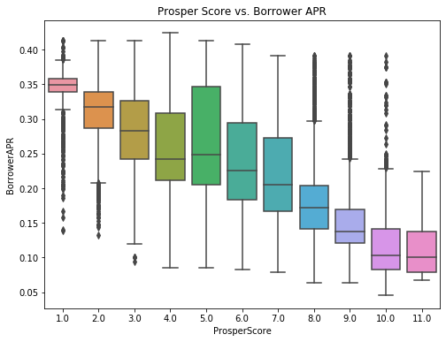

```python
# boxplot the relationship between prosper score and borrower apr
sb.boxplot(data = prosper_loan,x = 'ProsperScore',y = 'BorrowerAPR');
plt.xlabel('ProsperScore');
plt.ylabel('BorrowerAPR');
plt.title('Prosper Score vs. Borrower APR');
```

## Multivariate Exploration

### BorrowerAPR vs Prosper Score and LoanOriginal Amount

we can see that loans with larger amount are taken by people with higher credit rating.

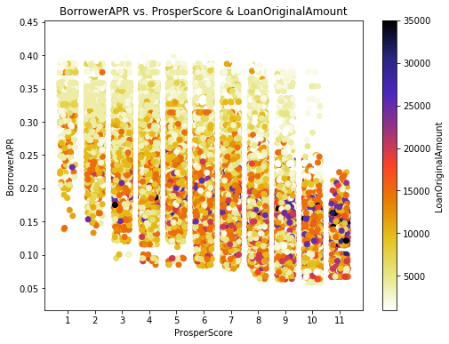

```python
cm = plt.cm.get_cmap('CMRmap_r')
plt.scatter(data = prosper_loan,
            x = 'ProsperScore_jitter', y = 'BorrowerAPR', c ='LoanOriginalAmount', cmap=cm)

plt.colorbar(label = 'LoanOriginalAmount')

plt.title('BorrowerAPR vs. ProsperScore & LoanOriginalAmount')

plt.xlabel('ProsperScore')

plt.ylabel('BorrowerAPR');

plt.xticks(np.arange(1,12), np.arange(1,12));
```

### different type of employment vs borrower APR and ProsperScore

1.Full-Time and part-time tend to have higher ProsperScore and lower BorrowerAPR

2.Not-Employed & Self-Employed tend to have lower ProsperScore and higher BorrowerAPR

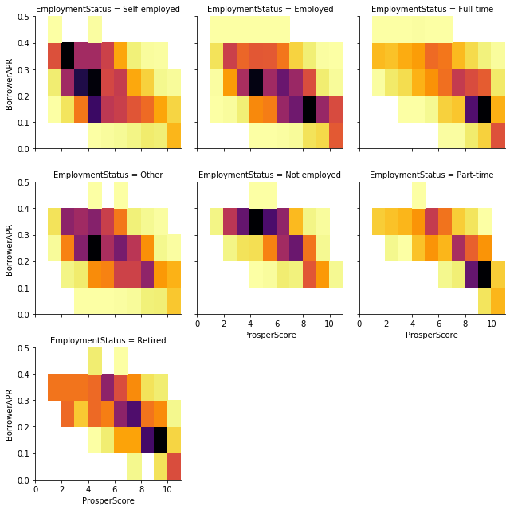

```python
def hist2dgrid(x, y, **kwargs):
    """ Quick hack for creating heat maps with seaborn's PairGrid. """
    palette = kwargs.pop('color')
    bins_x = np.arange(0, 12, 1)
    bins_y = np.arange(0, 0.6, 0.1)
    plt.hist2d(x, y, bins = [bins_x, bins_y], cmap = palette, cmin = 0.5)

    # create faceted heat maps on the EmploymentStatus
g = sb.FacetGrid(data = prosper_loan[prosper_loan['EmploymentStatus'] != 'Not available'],\
                 col = 'EmploymentStatus', col_wrap = 3, size = 3)
g.map(hist2dgrid, 'ProsperScore', 'BorrowerAPR', color = 'inferno_r')
g.set_xlabels('ProsperScore')
g.set_ylabels('BorrowerAPR');
```

```python
!jupyter nbconvert "Slide_Deck_loan.ipynb" --to slides --post serve --template output_toggle.tpl
```

[output not shown]